# Structural Divergence Analysis

Maria Laura Marcos, Julian Echave

# Introduction

We study the evolutionary divergence of proteins using the LF-ENM and comparing simulated mutants with experimental data.

We studied the ldh family. We used the ENM ANM with R0 = 7.5 to generate mutants. We used as reference for the ENM the protein with pdb code 1ldm. We simulated 10 mutants of this reference for each protein of the family. The ldh family is of the type alpha-beta and consists of the following proteins:

```
 [1] "1mlda" "2cmd"  "1ldna" "1llc"  "1llda" "9ldba" "5ldh"  "2ldx"
 [9] "1hlpa" "4mdha" "1bdma" "1ceqa" "1a5z"
```

# Structural divergence along sites

Here we study how structural divergence varies from site to site. We compare simulated data with empirical data.

### Mean z.local.score vs site

To measure structural divergence we use z.local.score profiles, which are the best for most families.

The following plot compares the mean z.local.score profiles, including standard errors (with .999 confidence level for the mean) *Warning: the effective number of data should be smaller than the actual data, especially for the experimental dataset because of several factors. We need to deal with this for quantitative analysis. Probably we’ll need to use bootstrapping to calculate standard errors non-parametrically*

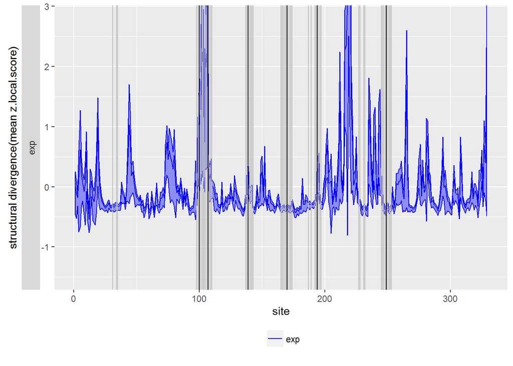

Black lines are the active sites and grey lines are their contacts

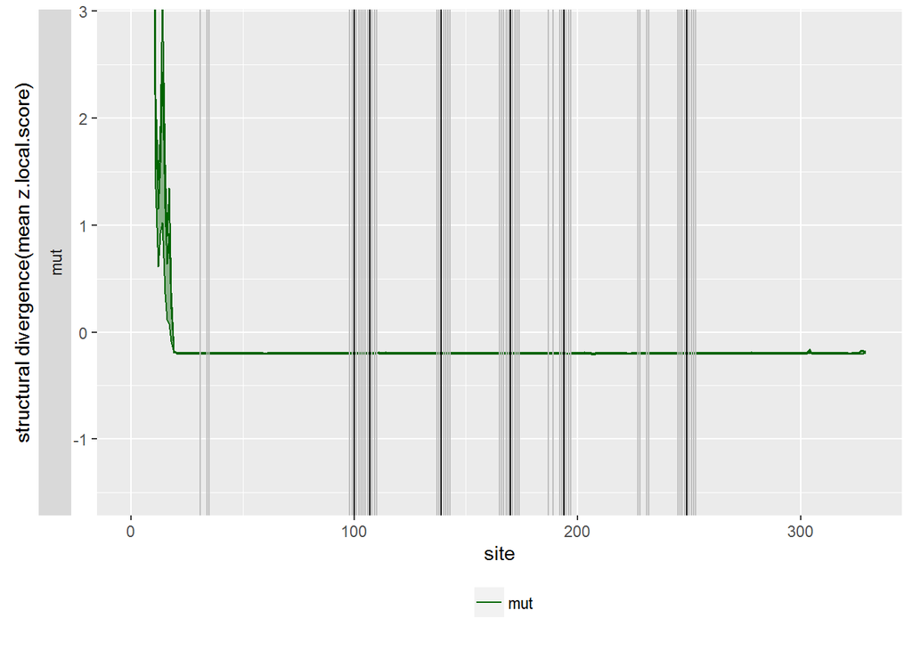

Black lines are the active sites and grey lines are their contacts

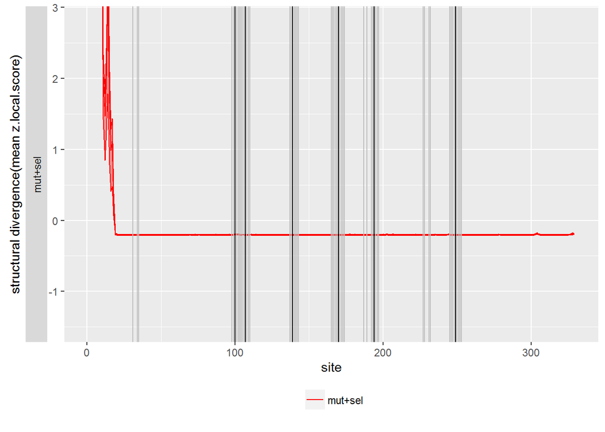

Black lines are the active sites and grey lines are their contacts

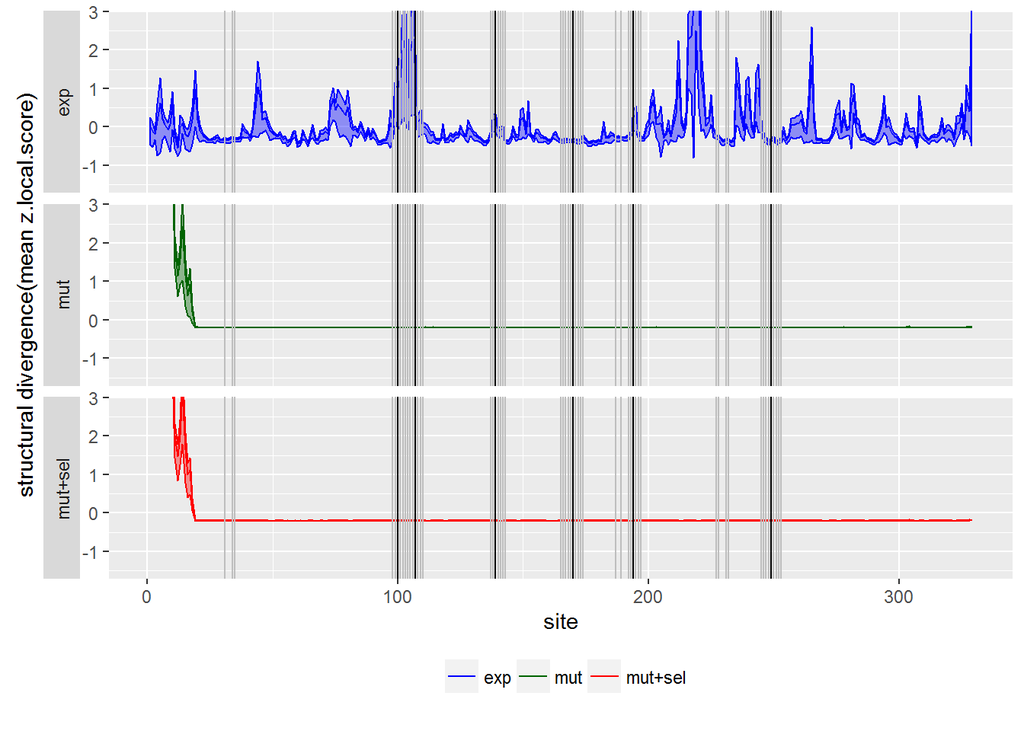

Black lines are the active sites and grey lines are their contacts

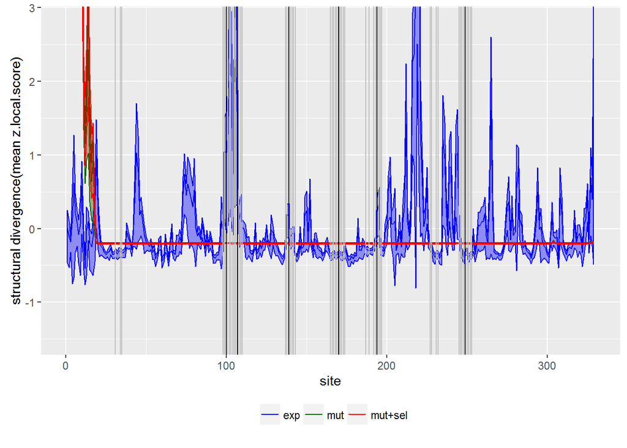

Black lines are the active sites and grey lines are their contacts

### Correlation between site profiles

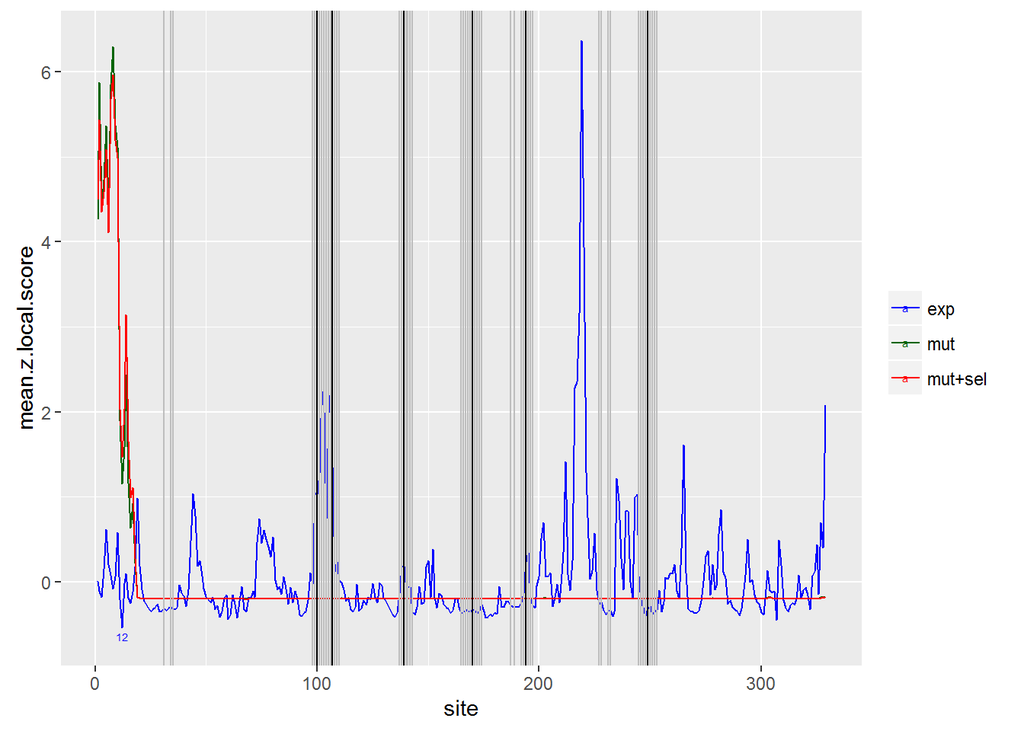

Black lines are the active sites and grey lines are their contacts

Correlation between profiles

| comparison | R |
| --- | --- |
| exp vs mut | 0.01 |
| exp vs strong | 0.01 |
| mut vs strong | 1.00 |

### Distances to the active sites

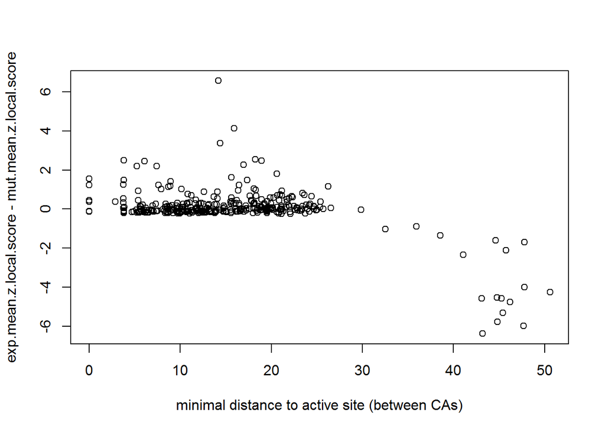

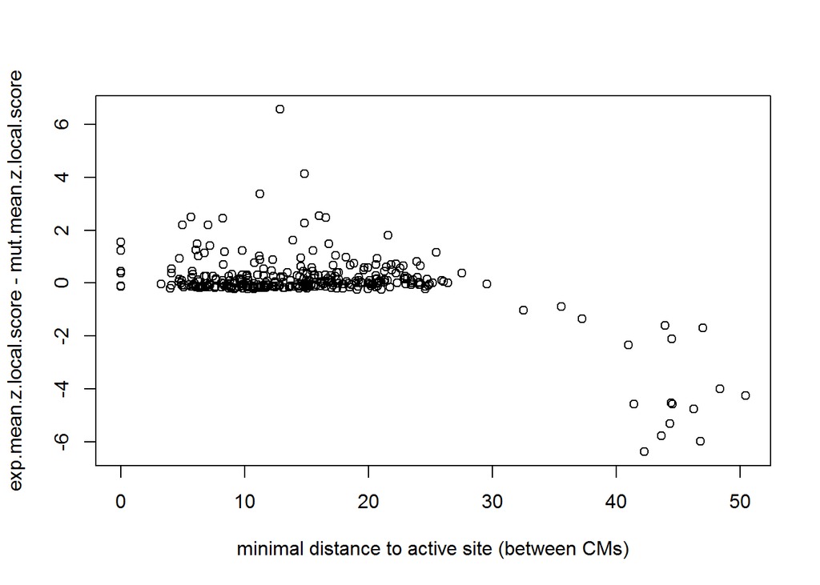

Correlation between differences in profiles and the minimal distance to the active site

| comparison | R |
| --- | --- |
| (exp - mut) vs min.da.CA | -0.56 |
| (exp - mut) vs min.da.CM | -0.57 |